# p8105_hw1_zz2900.Rmd

Zhenyu Zhou

2022-09-22

```r
library(tidyverse)
```

## Problem 1

Use the following code (in your RMarkdown file) to load the penguins dataset:

```r
#load the penguins dataset
data("penguins", package = "palmerpenguins")
```

- Short description:
  - There are 8 important variables in the penguins dataset. These 8 variables are species, island, bill_length_mm, bill_depth_mm, flipper_length_mm, body_mass_g, sex, year.
  - species is a factor variable: Adelie, Chinstrap, Gentoo.
  - island is a factor variable: Biscoe, Dream, and Torgersen islands.
  - bill_length_mm is a numeric variable.
  - bill_depth_mm is a numeric variable.
  - flipper_length_mm is a integer variable.
  - body_mass_g is a integer variable.
  - sex is a factor variable: male, female.
  - year is an integer variable.
- the size of the dataset (using nrow and ncol):
  - The row number of penguins is 344 and column number of penguins is 8.
- the mean flipper length:

```r
#drop NA from penguins data frame
noNA_penguins = drop_na(penguins)

#get the mean of fliiper length
flipperMean = mean(pull(noNA_penguins, flipper_length_mm))
```

- So the mean of fliiper length is 200.966967.

## Export my first scatterplot using ggsave.

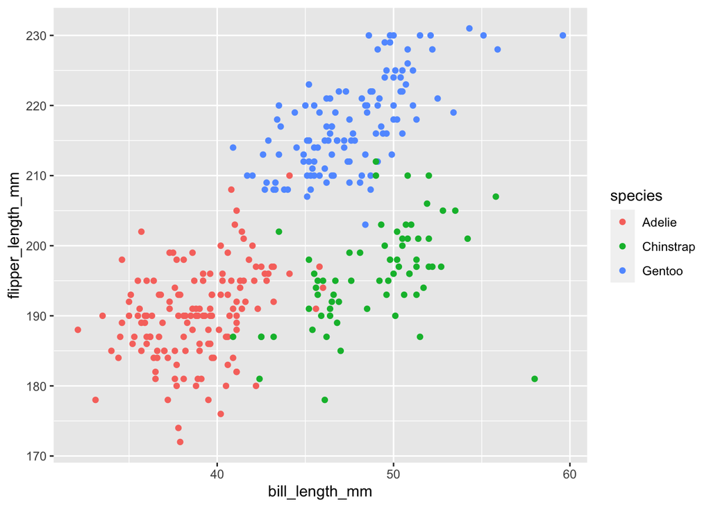

```r
## scatterplot of flipper_length_mm (y) vs bill_length_mm (x)
ggplot(noNA_penguins, aes(x = bill_length_mm, y = flipper_length_mm, color = species)) + geom_point()
```

```r
ggsave("penguins_scatter_plot.pdf")
```

## Problem 2

- Create my data frame:

  ```r
  # make my dataframe
  my_df = tibble(
  random_samp = rnorm(10),
  logical_vec = random_samp > 0,
  vec_char = c("a", "b", "c", "d", "e", "f", "g", "h", "i", "j"),
  factor_vector = factor(c("30", "40", "50", "60", "70", "80", "90", "20", "30", "40"))
  )
  ```

- Try to take the mean of each variable in your dataframe. What works and what doesn’t?

  **My Answer:**
  - The mean of random_samp is -0.2001117.
  - The mean of logical_vec is 0.2.
  - The mean of vec_char is NA.
  - The mean of factor_vector is NA.
  - In my datafram, we can get mean for random_samp and logical_vec. But we cannot get mean for vec_char and factor_vector.
- In some cases, you can explicitly convert variables from one type to another. Write a code chunk that applies the as.numeric function to the logical, character, and factor variables (please show this chunk but not the output). What happens, and why? Does this help explain what happens when you try to take the mean?

  ```r
  #applies the as.numeric function to the logical, character, and factor variables
  numeric_logical_vec = as.numeric(pull(my_df, logical_vec))
  numeric_vec_char = as.numeric(pull(my_df, vec_char))
  numeric_factor_vector = as.numeric(pull(my_df, factor_vector))
  ```

  **My Answer:**
  - When I use as.numeric function to the logical variables, TRUE turns to number 1 and FALSE turns to number 0.
  - When I use as.numeric function to the character variables, character variables turn to NAs.
  - When I use as.numeric function to the factor variables, factor variables turn to numbers.
  - Therefore, this help explain the mean of vec_char and the mean of factor_vector are NAs.
  - The mean of numeric_logical_vec is 0.2.
  - The mean of numeric_vec_char is NA.
  - The mean of numeric_factor_vector is 4.1.
  - After using as.numeric function, we can turn logical variables, and factor variables to numeric variables and get mean of them. But we cannot turn character variables to numeric variables and we cannot get mean of character variables.